# From the classical model to lunarcast

This vignette reproduces the classical analysis of the `sapi` series (six trend and seasonal structures crossed with three calendar designs, 18 models fitted to 2004–2024 and tested on 2025), adds lunarcast to it, and then shows why a single test year is not enough to compare them.

```r
library(lunarcast)
adha  <- holiday_dates("idul_adha")
fitri <- holiday_dates("idul_fitri")
train <- window(sapi, end = c(2024, 12))
test  <- window(sapi, start = c(2025, 1))
```

## Six structures and three calendar designs

Each model is a regression with ARIMA errors on the original scale, so the holiday effects are additive and the same in every year. The six structures combine a trend and a seasonal component:

| Model | Trend | Seasonality |
| --- | --- | --- |
| m1 | deterministic ($\beta_0 + \beta_1 t$) | 11 monthly dummies |
| m2 | deterministic | Fourier terms, $K = 5$ |
| m3 | stochastic (differencing) | 11 monthly dummies |
| m4 | stochastic | Fourier terms, $K = 5$ |
| m5 | deterministic | seasonal ARIMA |
| m6 | stochastic | seasonal ARIMA |

The calendar part $C_t$ has three designs:

| Design | `design` | Calendar part $C_t$ |
| --- | --- | --- |
| D1, month dummy | `"dummy"` | $\alpha V_t$, with $V_t = 1$ if month $t$ contains Eid al-Adha |
| D2, lead–lag dummies | `"leadlag"` | $\alpha_{-1} V_{t+1} + \alpha_0 V_t + \alpha_{+1} V_{t-1}$ |
| D3, proportional windows | `"window"` | $\alpha_{\text{before}}\,\mathrm{PRE}_t(w) + \alpha_{\text{holiday}}\,\mathrm{HOL}_t$ |

In D3, $\mathrm{PRE}_t(w)$ is the share of the $w$ days before Eid al-Adha that falls in month $t$ and $\mathrm{HOL}_t$ the share of the holiday and the three tasyrik days (Bell and Hillmer, 1983). The window length $w$ is chosen from 7, 14, 21 and 28 days: every structure ranks the four by AICc, and the length chosen by most structures is used for all six.

```r
classic <- calvar_classic_all(train, adha, design = c("dummy", "leadlag", "window"))
classic
```

```
#> 18 classical calendar variation models
#>  model      trend  season  ARIMA              AICc   before      holiday      after
#>  m1_dummy   det.   dummy   (3,0,2)            1783.9             29.83 (1.81)
#>  m2_dummy   det.   Fourier (3,0,2)            1781.5             29.68 (1.80)
#>  m3_dummy   stoch. dummy   (2,1,2)            1774.4             29.69 (1.81)
#>  m4_dummy   stoch. Fourier (2,1,2)            1772.2             29.70 (1.82)
#>  m5_dummy   det.   stoch.  (1,0,2)(2,0,0)[12] 1655.8             17.53 (1.95)
#>  m6_dummy   stoch. stoch.  (1,1,1)(1,0,2)[12] 1647.5             18.90 (2.06)
#>  m1_leadlag det.   dummy   (5,0,2)            1755.0 2.80 (1.65) 29.39 (1.75) 6.44 (1.83)
#>  m2_leadlag det.   Fourier (5,0,2)            1768.7 3.24 (1.60) 30.51 (1.64) 7.67 (1.67)
#>  m3_leadlag stoch. dummy   (5,1,2)            1734.8 2.39 (1.67) 28.16 (1.68) 3.98 (1.78)
#>  m4_leadlag stoch. Fourier (5,1,2)            1732.6 2.39 (1.68) 28.15 (1.68) 3.97 (1.78)
#>  m5_leadlag det.   stoch.  (1,0,2)(2,0,0)[12] 1649.4 5.39 (1.88) 20.52 (2.01) 4.67 (1.85)
#>  m6_leadlag stoch. stoch.  (2,1,2)(0,0,2)[12] 1640.9 7.11 (1.94) 21.51 (1.97) 3.91 (1.80)
#>  m1_window  det.   dummy   (4,0,3)            1711.8 5.61 (2.41) 25.59 (2.27)
#>  m2_window  det.   Fourier (4,0,3)            1709.4 5.60 (2.41) 25.60 (2.27)
#>  m3_window  stoch. dummy   (3,1,3)            1701.6 5.62 (2.41) 25.58 (2.27)
#>  m4_window  stoch. Fourier (3,1,3)            1699.3 5.61 (2.41) 25.59 (2.27)
#>  m5_window  det.   stoch.  (1,0,1)(2,0,0)[12] 1598.6 7.32 (2.33) 21.10 (1.64)
#>  m6_window  stoch. stoch.  (2,1,2)(2,0,0)[12] 1593.2 6.46 (2.31) 21.83 (1.68)
#> Windows: before [-14, -1] days, holiday [0, +3] days
#> Trend: det. = deterministic, stoch. = stochastic; seasonality: stoch. = seasonal ARIMA.
#> Holiday effects: estimate (s.e.); with the window design they are effects of a full window.
#> Note: AICc is comparable only between models with the same order of differencing.
```

The AICc of the window lengths:

```r
aicc_w <- reshape(classic$window_aicc[, c("model", "w", "AICc")],
                  idvar = "model", timevar = "w", direction = "wide")
names(aicc_w) <- c("model", paste("w =", c(7, 14, 21, 28)))
aicc_w
```

```
#>    model    w = 7   w = 14   w = 21   w = 28
#> 1     m1 1711.973 1711.780 1713.538 1740.679
#> 5     m2 1746.501 1709.425 1711.181 1712.199
#> 9     m3 1701.815 1701.623 1703.392 1704.419
#> 13    m4 1699.495 1699.327 1701.090 1702.137
#> 17    m5 1602.238 1598.647 1598.365 1599.603
#> 21    m6 1598.094 1593.170 1594.908 1596.227
```

Five of the six structures prefer $w = 14$ days. Within every structure the proportional windows give the smallest AICc of the three designs (for m6, 1593.2 against 1647.5 with the month dummy). The effect of the two weeks before the holiday is small (about 6 index points for a full window) but the holiday window carries 21 to 26 points, and it is spread correctly over two months when Eid al-Adha falls at the end of a month. The lead–lag dummies show the same thing more crudely: the months before and after the holiday month have small positive effects. With seasonal ARIMA errors (m5, m6) part of the holiday effect is carried by the seasonal autoregression, so the estimated effects are smaller than in m1 to m4.

## lunarcast on the same data

```r
lc <- lunarcast(train, list(adha = adha, fitri = fitri))
lc
```

```
#> lunarcast: Regression with ARIMA(5,1,1)(2,0,0)[12] errors | AICc = -278.5
#> Structure (cv, 1se): stochastic + SARMA(2,0,0), d = 1
#> Cross-validated RMSE of the candidate structures:
#>                  structure RMSE   SE
#>  stochastic + fourier(K=2) 6.78 1.33
#>         stochastic + dummy 7.47 1.25
#>  stochastic + SARMA(2,0,0) 7.74 1.85
#>          stochastic + none 8.24 1.70
#>
#> adha: two-level effect, window [-3, +7] days, level 2 = ses (CV-RMSE 0.14)
#>       event   alpha     se ratio
#>  2004-02-01 -0.0683 0.1838 0.934
#>  2005-01-21  0.1805 0.1200 1.198
#>  2006-01-10 -0.1572 0.1036 0.855
#>  2006-12-31 -0.5372 0.1867 0.584
#>  2007-12-20  0.1838 0.0970 1.202
#>  2008-12-08  0.2479 0.0988 1.281
#>  2009-11-27  0.4905 0.1459 1.633
#>  2010-11-17  0.5176 0.0984 1.678
#>  2011-11-06  0.5785 0.1008 1.783
#>  2012-10-26  0.8263 0.1219 2.285
#>  2013-10-15  0.9417 0.0989 2.564
#>  2014-10-05  0.8655 0.0997 2.376
#>  2015-09-24  0.9922 0.1115 2.697
#>  2016-09-12  1.0119 0.1023 2.751
#>  2017-09-01  1.2350 0.1286 3.438
#>  2018-08-22  1.1740 0.0985 3.235
#>  2019-08-11  1.1617 0.0989 3.195
#>  2020-07-31  1.1154 0.1402 3.051
#>  2021-07-20  1.0711 0.0990 2.919
#>  2022-07-10  1.0070 0.0985 2.737
#>  2023-06-29  1.1524 0.1420 3.166
#>  2024-06-17  0.8365 0.1020 2.308
#>
#> fitri: constant effect, window [-28, +3] days
#>  alpha     se ratio
#>  0.148 0.0363  1.16
```

## One test year: 2025

```r
fc_classic <- forecast(classic, h = length(test))
fc_lc      <- forecast(lc, h = length(test))
acc <- do.call(forecast_accuracy,
               c(list(actual = test), fc_classic, list(lunarcast = fc_lc)))
acc[, -1] <- round(acc[, -1], 2)
acc[order(acc$RMSE), ]
```

```
#>         model RMSE  MAE  MAPE sMAPE
#> 19  lunarcast 1.83 1.42  5.90  5.93
#> 6    m6_dummy 2.43 1.72  6.65  7.15
#> 12 m6_leadlag 2.63 1.86  7.92  7.89
#> 18  m6_window 3.14 2.64 10.46 10.59
#> 5    m5_dummy 3.55 2.68 12.70 11.49
#> 11 m5_leadlag 3.85 3.07 14.40 12.98
#> 16  m4_window 3.90 3.27 14.87 13.66
#> 15  m3_window 3.92 3.29 14.92 13.69
#> 10 m4_leadlag 4.36 3.48 15.94 14.27
#> 17  m5_window 4.39 3.69 16.64 14.94
#> 9  m3_leadlag 4.40 3.48 15.92 14.21
#> 3    m3_dummy 4.67 3.57 17.26 15.19
#> 4    m4_dummy 4.67 3.58 17.34 15.29
#> 14  m2_window 4.99 4.02 19.14 16.60
#> 13  m1_window 5.01 4.04 19.19 16.63
#> 1    m1_dummy 6.13 4.54 22.07 18.25
#> 2    m2_dummy 6.64 4.95 23.91 19.48
#> 8  m2_leadlag 6.91 5.34 25.34 20.95
#> 7  m1_leadlag 7.05 5.29 25.92 21.34
```

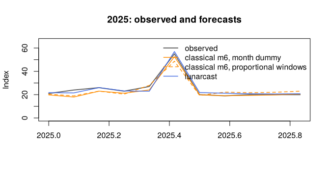

```r
plot(test, ylim = c(0, max(test, fc_lc$mean) * 1.15), lwd = 2, col = "grey40",
     xlab = "", ylab = "Index", main = "2025: observed and forecasts")
lines(fc_classic$m6_dummy$mean, col = "darkorange", lwd = 1.5)
lines(fc_classic$m6_window$mean, col = "darkorange", lwd = 1.5, lty = 2)
lines(fc_lc$mean, col = "royalblue", lwd = 1.5)
legend("topright", c("observed", "classical m6, month dummy",
                     "classical m6, proportional windows", "lunarcast"),
       bty = "n", col = c("grey40", "darkorange", "darkorange", "royalblue"),
       lwd = c(2, 1.5, 1.5, 1.5), lty = c(1, 1, 2, 1))
```

A single test year is a fragile basis for comparison. In 2025 Eid al-Adha fell in June for the third year in a row, the ideal situation for a seasonal ARIMA model, which simply repeats last year’s June, so the classical m6 model with the month dummy also does well, even better than with proportional windows. The difficult years are those in which the holiday moves to another month, and they do not occur every year.

## Fourteen test years: rolling origin

`rolling_origin()` refits every model at the end of each year from 2011 to 2024 and forecasts the following year, so that 14 test years (2012 to 2025, 167 months) are used. With proportional windows, the length of the window before the holiday is chosen again by AICc at every origin. Running it for all models takes some time; the results for `sapi` are stored in the package:

```r
r <- read.csv(system.file("extdata", "rolling_sapi.csv", package = "lunarcast"))
r$model <- factor(r$model, levels = unique(r$model))
s <- rolling_summary(r)
s[order(s[, "all"]), ]
```

```
#>                      all holiday other moving stable mean_year median_year
#> lunarcast           4.94    8.30  4.50   6.00   4.22      4.53        4.39
#> lunarcast_none      5.15    9.45  4.55   6.10   4.52      4.81        4.84
#> lunarcast_aicc      5.73   12.28  4.70   6.13   5.50      5.25        4.64
#> classic_m6_window   7.30   19.66  4.77   9.10   6.06      6.61        5.11
#> classic_m5_window   7.31   20.04  4.64   8.89   6.25      6.80        5.94
#> lunarcast_split     7.76   19.17  5.67   8.12   7.55      7.05        6.35
#> classic_m6          7.95   20.25  5.61   8.82   7.42      7.00        5.75
#> classic_m5_leadlag  8.01   20.27  5.69   8.80   7.52      7.19        5.59
#> classic_m5          8.04   20.54  5.65   8.75   7.61      7.20        5.68
#> classic_m6_leadlag  8.05   21.09  5.48   9.00   7.47      7.25        5.97
#> classic_m3_window   9.26   25.25  5.93   9.33   9.22      8.87        9.20
#> classic_m4_window   9.27   25.16  5.98   9.28   9.26      8.87        9.23
#> classic_m4_leadlag  9.41   24.56  6.43   9.55   9.33      8.89        9.40
#> classic_m3_leadlag  9.43   24.65  6.44   9.61   9.33      8.92        9.32
#> classic_m2_window   9.68   27.27  5.85  10.16   9.39      9.27        9.57
#> classic_m4          9.73   25.83  6.50  10.38   9.34      9.31       10.31
#> classic_m3          9.75   25.91  6.50  10.43   9.34      9.33       10.27
#> classic_m1_window   9.82   27.26  6.11  10.27   9.56      9.43        9.47
#> classic_m1_leadlag  9.92   26.00  6.75  10.31   9.69      9.57        9.81
#> classic_m2_leadlag 10.06   26.46  6.81  10.36   9.88      9.67       10.25
#> classic_m2         10.27   26.55  7.12  11.18   9.73      9.86        9.94
#> classic_m1         10.42   27.12  7.15  11.29   9.90      9.98       10.30
```

The lunarcast rows differ only in how the seasonal structure is chosen: by AICc (`lunarcast_aicc`), fixed without seasonality (`lunarcast_none`) or by cross-validation with the one-standard-error rule (`lunarcast`, the default). `lunarcast_split` gives Eid al-Adha the two windows of the classical window design, the 14 days before the holiday and the holiday with the tasyrik days, each with its own effect. The code that produced the file is shown at the end of this vignette.

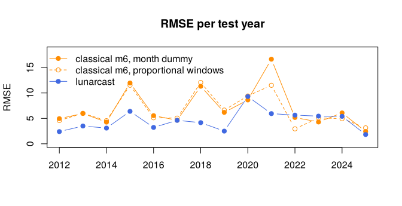

```r
yearly <- tapply((r$pred - r$actual)^2, list(r$year, r$model),
                 function(v) sqrt(mean(v)))
years <- as.numeric(rownames(yearly))
show  <- c("classic_m6", "classic_m6_window", "lunarcast")
plot(years, yearly[, "classic_m6"], type = "b", pch = 19, col = "darkorange",
     ylim = c(0, max(yearly[, show]) * 1.1),
     xlab = "", ylab = "RMSE", main = "RMSE per test year")
lines(years, yearly[, "classic_m6_window"], type = "b", pch = 1, lty = 2,
      col = "darkorange")
lines(years, yearly[, "lunarcast"], type = "b", pch = 19, col = "royalblue")
legend("topleft", c("classical m6, month dummy", "classical m6, proportional windows",
                    "lunarcast"), col = c("darkorange", "darkorange", "royalblue"),
       pch = c(19, 1, 19), lty = c(1, 2, 1), bty = "n")
```

What the table shows:

- Proportional windows improve every classical structure. The best classical model is now m6 with proportional windows, with an RMSE of 7.30 instead of 7.95 for the month dummy. Lead–lag dummies hardly help (8.05 for m6).
- The gain stays small in the months that matter: in holiday months the RMSE of m6 falls only from 20.25 to 19.66, because the effect is still the same in every year. lunarcast lowers the overall RMSE to 4.94 and the RMSE in holiday months to 8.30.
- The two classical windows do not help inside lunarcast either: `lunarcast_split` has an RMSE of 7.76, against 4.94 for the single window that lunarcast chooses by AICc, $(-3, +7)$, which also covers the week after the holiday. The option is there to reproduce a chosen window design, not as a better default.
- Choosing the structure by AICc picks seasonal ARIMA errors at most origins and gives a clearly worse forecast than cross-validation: a good in-sample fit is not the same as a good forecast.

The notebook that introduced the three designs evaluated test years 2019 to 2025 by the mean of the yearly RMSEs. On that protocol the package gives the same values for the month dummy and the lead–lag dummies of m6 (7.06 and 7.20); for the proportional windows it gives 6.24 rather than 6.16, because here the window length is chosen again at every origin instead of once from the data up to 2024:

```r
r19 <- r[r$year >= 2019, ]
r19$model <- droplevels(r19$model)
rolling_summary(r19)[c("classic_m6", "classic_m6_leadlag", "classic_m6_window",
                       "lunarcast"), c("all", "mean_year")]
```

```
#>                     all mean_year
#> classic_m6         8.31      7.06
#> classic_m6_leadlag 8.23      7.20
#> classic_m6_window  6.94      6.24
#> lunarcast          5.66      5.15
```

## How the rolling-origin results were produced

```r
hol  <- list(adha = adha, fitri = fitri)
spec <- classic$spec[classic$spec$design == "dummy", ]
classic_design <- function(design, suffix) {
  m <- lapply(seq_len(6), function(i) {
    force(i)
    function(y, h) forecast(calvar_classic(y, adha, spec$trend[i], spec$season[i],
                                           design = design), h = h)$mean
  })
  setNames(m, paste0("classic_m", 1:6, suffix))
}
classic_models <- c(classic_design("dummy", ""),
                    classic_design("leadlag", "_leadlag"),
                    classic_design("window", "_window"))

# the lunarcast variants share the calendar selected at each origin
lunarcast_variant <- function(...) {
  function(y, h) {
    base <- lunarcast(y, hol, select = "aicc")
    fit  <- lunarcast(y, hol, window = base$window, effect = base$effect, ...)
    forecast(fit, h = h)$mean
  }
}
lunarcast_models <- list(
  lunarcast_aicc  = function(y, h) forecast(lunarcast(y, hol, select = "aicc"), h = h)$mean,
  lunarcast_none  = lunarcast_variant(season = "none", select = "aicc"),
  lunarcast       = lunarcast_variant(),
  lunarcast_split = function(y, h)
    forecast(lunarcast(y, hol, window = list(adha = list(before = c(-14, -1),
                                                        holiday = c(0, 3)))),
             h = h)$mean
)
r <- rolling_origin(sapi, adha, c(classic_models, lunarcast_models), first = 2012)
rolling_summary(r)
```

The same code is in `data-raw/rolling_sapi.R` in the package repository.

## Reference

Bell, W. R. and Hillmer, S. C. (1983). Modeling time series with calendar variation. *Journal of the American Statistical Association*, 78(383), 526–534.